# COVID_detection_CNN (1)

Description Background and Context

Covid-19 is a fast-growing disease that affects human health severely. Patients diagnosed with this condition suffer from lung infections. The medical community has recently released vaccines that have a slower effect in increasing immunity. This virus has impacted various countries' human health and financial standards. Deep learning algorithms have recently used image classification to identify medical images. Convolutional Neural Networks (CNN) can be widely utilized to identify COVID-19 to assist radiologists in medical analysis by classifying patients who are healthy, have viral pneumonia, or are affected by COVID using X-ray pictures of the lungs. Objective

The aim of this project is to build a Convolutional Neural Network to differentiate an X-ray image of a normal person from an unhealthy one.

Data Description

This dataset contains training set images of 3 classes which are converted into numpy arrays. The dataset comprises 3 classes: COVID-19: The patient who is affected due to covid. Viral Pneumonia: This is a viral fever that has similar characteristics to Covid but is not covid. Normal- A healthy Person. The data file names are: CovidImages.npy CovidLabels.csv Due to the large volume of data, the images were converted to the CovidImages.npy file and the labels are also put into CovidLabels.csv so that you can work on the data/project seamlessly without having to worry about the high data volume. Guide to solve the project seamlessly

Here are the points which will help you to solve the problem efficiently:

Read the problem statement carefully Download the dataset from the Olympus platform. Upload the "CovidImages.npy" and “CovidLabels.csv” files to google drive. You can set runtime type to “GPU” in Google Colab so that the code will run faster as you will be using CNN to fit your model.

```python
from google.colab import drive
drive.mount('/content/drive/')
```

```python
import pandas as pd
import tensorflow as tf
import numpy as np
import cv2

import matplotlib.pyplot as plt
import seaborn as sns

from sklearn.model_selection import train_test_split
from keras.preprocessing.image import ImageDataGenerator
from sklearn.preprocessing import LabelEncoder
from keras.utils import to_categorical

from keras.models import Sequential
from sklearn.metrics import confusion_matrix
from sklearn.metrics import classification_report, accuracy_score

from keras.layers import Dropout
from keras.optimizers import Adam
from keras.layers import Conv2D, MaxPooling2D, Flatten, Dense
```

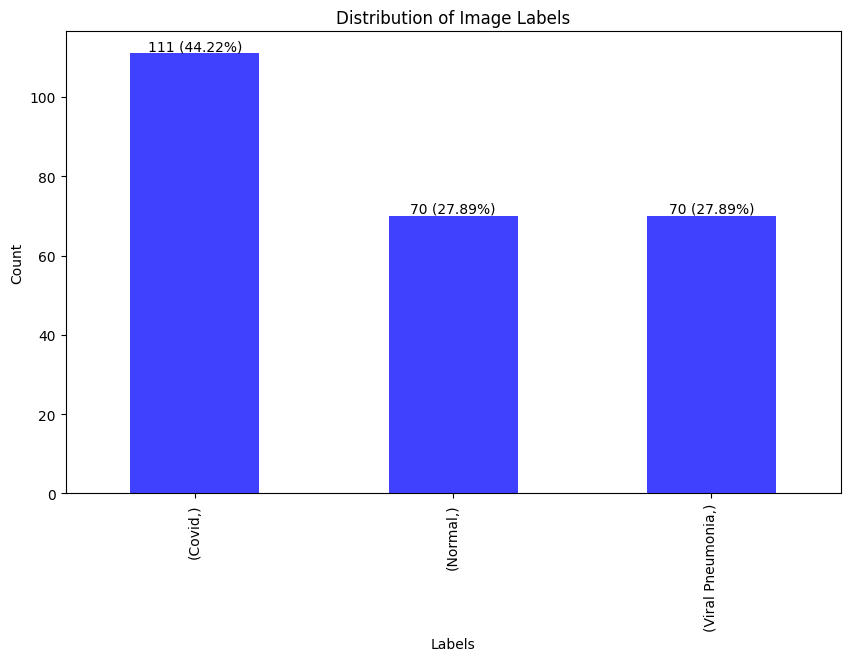

```python
image_labels = pd.read_csv('/content/drive/My Drive/ComputerVisionProject/CovidLabels.csv')

# Calculate the value counts and percentages
label_counts = image_labels.value_counts()
label_percentages = label_counts / label_counts.sum() * 100

# Plot the value counts and percentages
plt.figure(figsize=(10, 6))
ax = label_counts.plot(kind='bar', color='blue', alpha=0.75)

# Add count labels on top of bars
for i, v in enumerate(label_counts):
    ax.text(
        i,
        v,
        str(v)+' ('+ str(np.round(100*v/label_counts.sum(),2))+'%)',
        ha='center',
        va='bottom'
    )

plt.xlabel('Labels')
plt.ylabel('Count')
plt.title('Distribution of Image Labels')
plt.show()
```

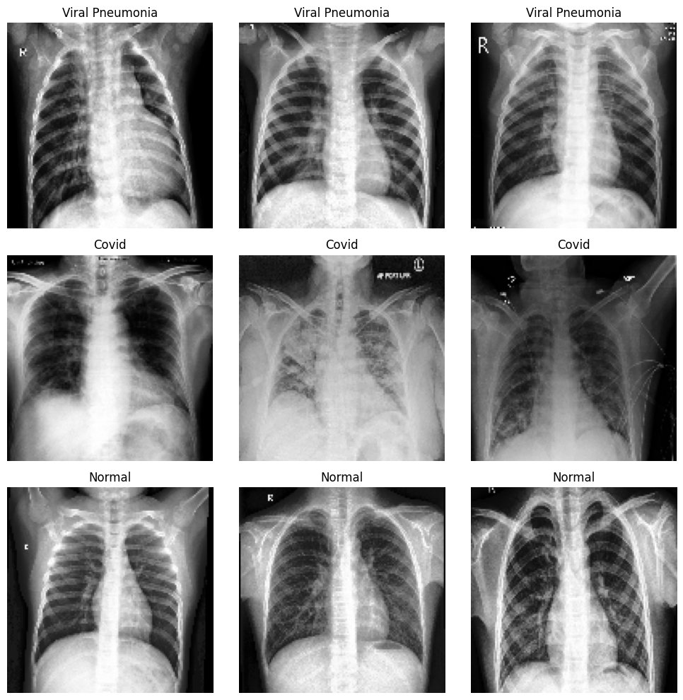

```python
image_labels = pd.read_csv('/content/drive/My Drive/ComputerVisionProject/CovidLabels.csv')

images = np.load('/content/drive/My Drive/ComputerVisionProject/CovidImages.npy')
# Get unique labels
unique_labels = image_labels['Label'].unique()

# Plot three images of each type
fig, axes = plt.subplots(len(unique_labels), 3, figsize=(10, 10))

for i, label in enumerate(unique_labels):
    # Randomly select three images
    random_images = np.random.choice(range(np.sum([image_labels['Label'] == label])), size=3, replace=False)
    # Select images with the current label
    label_images = images[image_labels['Label'] == label][random_images,:,:,:]

    # # Select images with the current label
    # label_images = images[image_labels['label'] == label]

    for j, image in enumerate(label_images):
        ax = axes[i, j]
        ax.imshow(image)
        ax.axis('off')
        ax.set_title(label)

plt.tight_layout()
plt.show()
# print(np.shape(images))

# plt.imshow(images[0,:,:,:])
# plt.axis('off')
# plt.show()
```

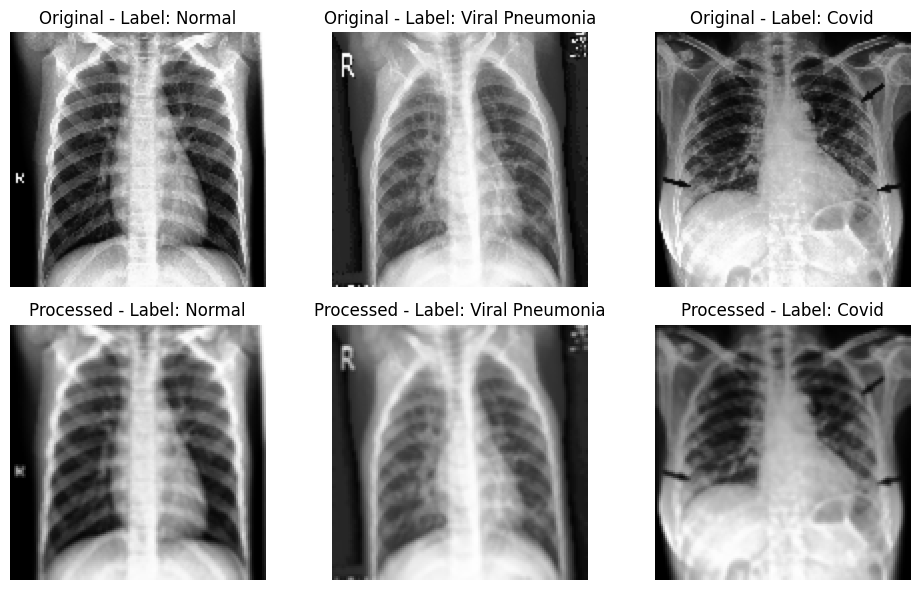

```python
# Apply preprocessing steps
processed_images = []
for image in images:
    # Apply Gaussian blurring
    blurred_image = cv2.GaussianBlur(image, (3, 3), 0)

    # Apply normalization
    normalized_image = blurred_image / 255.0

    processed_images.append(normalized_image)

processed_images = np.array(processed_images)

# Plot a sample of original and processed images
fig, axes = plt.subplots(nrows=2, ncols=3, figsize=(10, 6))
sample_indices = np.random.choice(range(len(images)), size=3, replace=False)

for i, index in enumerate(sample_indices):
    # Plot original image
    axes[0, i].imshow(images[index])
    axes[0, i].set_title(f'Original - Label: {image_labels.iloc[index]["Label"]}')
    axes[0, i].axis('off')

    # Plot processed image
    axes[1, i].imshow(processed_images[index])
    axes[1, i].set_title(f'Processed - Label: {image_labels.iloc[index]["Label"]}')
    axes[1, i].axis('off')

plt.tight_layout()
plt.show()

# Split the data into train and test sets
X_train, X_test, y_train, y_test = train_test_split(processed_images, image_labels['Label'], test_size=0.2, random_state=42)
```

```python
# Initialize the label encoder
label_encoder = LabelEncoder()

# Fit and transform the training labels
y_train_encoded = label_encoder.fit_transform(y_train)

# Transform the test labels
y_test_encoded = label_encoder.transform(y_test)

# Convert encoded labels to one-hot vectors
y_train_one_hot = to_categorical(y_train_encoded)
y_test_one_hot = to_categorical(y_test_encoded)

print("Shape of X_train:", X_train.shape)
print("Shape of X_test:", X_test.shape)
print("Shape of y_train_one_hot:", y_train_one_hot.shape)
print("Shape of y_test_one_hot:", y_test_one_hot.shape)

# Reshape the data
if len(X_train.shape) == 3:
    X_train = X_train.reshape(X_train.shape + (1,))
if len(X_test.shape) == 3:
    X_test = X_test.reshape(X_test.shape + (1,))
```

```
Shape of X_train: (200, 128, 128, 3)
Shape of X_test: (51, 128, 128, 3)
Shape of y_train_one_hot: (200, 3)
Shape of y_test_one_hot: (51, 3)
```

```python
# Define the model
model = Sequential()

# Add the convolutional layers
model.add(Conv2D(32, (3, 3), activation='relu', input_shape=(128, 128, 3)))
model.add(MaxPooling2D(pool_size=(2, 2)))

model.add(Conv2D(64, (3, 3), activation='relu'))
model.add(MaxPooling2D(pool_size=(2, 2)))

# Flatten the feature maps
model.add(Flatten())

# Add the fully connected layers
model.add(Dense(128, activation='relu'))
model.add(Dense(3, activation='softmax'))

# Compile the model
model.compile(loss='categorical_crossentropy', optimizer='adam', metrics=['accuracy'])

# Print the model summary
model.summary()
```

```
Model: "sequential_10"
_________________________________________________________________
 Layer (type)                Output Shape              Param #
=================================================================
 conv2d_26 (Conv2D)          (None, 126, 126, 32)      896

 max_pooling2d_26 (MaxPoolin  (None, 63, 63, 32)       0
 g2D)

 conv2d_27 (Conv2D)          (None, 61, 61, 64)        18496

 max_pooling2d_27 (MaxPoolin  (None, 30, 30, 64)       0
 g2D)

 flatten_10 (Flatten)        (None, 57600)             0

 dense_20 (Dense)            (None, 128)               7372928

 dense_21 (Dense)            (None, 3)                 387

=================================================================
Total params: 7,392,707
Trainable params: 7,392,707
Non-trainable params: 0
_________________________________________________________________
```

```python
# Train the model
model.fit(X_train, y_train_one_hot, batch_size=32, epochs=10, validation_data=(X_test, y_test_one_hot))

# Evaluate the model
loss, accuracy = model.evaluate(X_test, y_test_one_hot)
print("Test Loss:", loss)
print("Test Accuracy:", accuracy)
```

```
Test Loss: 0.18136847019195557
Test Accuracy: 0.9411764740943909
```

```
[0 2 0 2 0 1 1 2 2 0 0 1 1 0 2 1 1 2 0 1 1 0 0 2 0 2 2 2 2 1 1 2 1 1 2 0 2
 0 0 0 0 0 0 0 1 2 0 0 1 2 0]
```

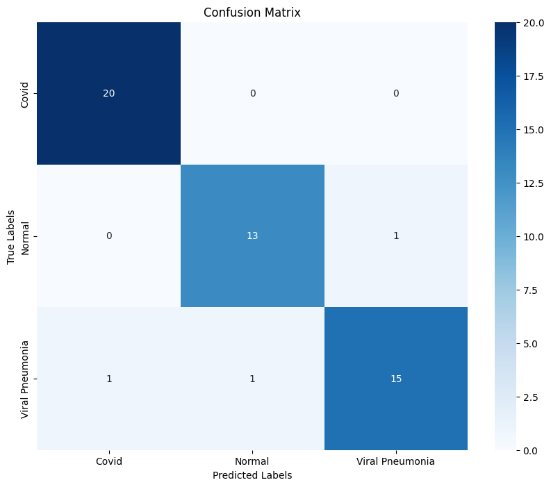

```python
# Get the model's predictions for the test data
y_pred_probabilities = model.predict(X_test)
y_pred = np.argmax(y_pred_probabilities, axis=1)
predicted_labels = [label_encoder.classes_[label] for label in y_pred]

print(y_pred)

# Create the confusion matrix
cm = confusion_matrix(y_test.tolist(), predicted_labels)

# Plot the confusion matrix
plt.figure(figsize=(10, 8))
sns.heatmap(cm, annot=True, fmt="d", cmap="Blues", xticklabels=label_encoder.classes_, yticklabels=label_encoder.classes_)
plt.xlabel('Predicted Labels')
plt.ylabel('True Labels')
plt.title('Confusion Matrix')
plt.show()
```

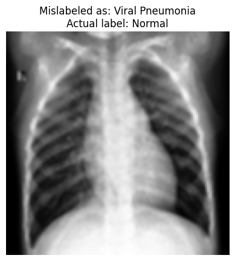

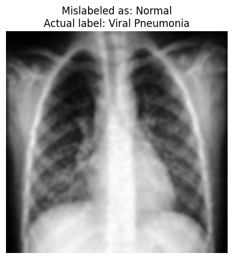

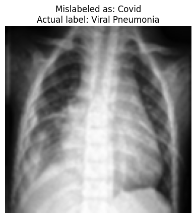

```python
# Find the indices of mislabeled images
mislabeled_indices = np.where(y_pred != y_test_encoded)[0]

# Print the mislabeled images
for index in mislabeled_indices:
    mislabeled_image = X_test[index]
    mislabeled_label = predicted_labels[index]  # Use mapped_labels if available, otherwise use y_pred
    actual_label = y_test.tolist()[index]

    # Display the mislabeled image
    plt.imshow(mislabeled_image, cmap='gray')
    plt.title('Mislabeled as: ' + mislabeled_label + '\nActual label: ' + actual_label)
    plt.axis('off')
    plt.show()
```

```python
# Get the model's predictions for the test data
y_pred = np.argmax(model.predict(X_test), axis=1)

# Compute accuracy
accuracy = accuracy_score(y_test_encoded, y_pred)

# Generate classification report
classification_rep = classification_report(y_test_encoded, y_pred)

# Print the metrics
print("Accuracy:", accuracy)
print("\nClassification Report:\n", classification_rep)
```

```
Accuracy: 0.9411764705882353

Classification Report:
               precision    recall  f1-score   support

           0       0.95      1.00      0.98        20
           1       0.93      0.93      0.93        14
           2       0.94      0.88      0.91        17

    accuracy                           0.94        51
   macro avg       0.94      0.94      0.94        51
weighted avg       0.94      0.94      0.94        51
```

```python
# Define the improved model
improved_model = Sequential()

# Add the convolutional layers
improved_model.add(Conv2D(32, (3, 3), activation='relu', input_shape=(128, 128, 3)))
improved_model.add(MaxPooling2D(pool_size=(2, 2)))

improved_model.add(Conv2D(64, (3, 3), activation='relu'))
improved_model.add(MaxPooling2D(pool_size=(2, 2)))

improved_model.add(Conv2D(128, (3, 3), activation='relu'))
improved_model.add(MaxPooling2D(pool_size=(2, 2)))

# Flatten the feature maps
improved_model.add(Flatten())

# Add dropout regularization
improved_model.add(Dropout(0.5))

# Add the fully connected layers
improved_model.add(Dense(256, activation='relu'))
improved_model.add(Dense(3, activation='softmax'))

# Compile the model with a lower learning rate
optimizer = Adam(learning_rate=0.001)
improved_model.compile(loss='categorical_crossentropy', optimizer=optimizer, metrics=['accuracy'])

# Apply data augmentation
data_generator = ImageDataGenerator(rotation_range=10, width_shift_range=0.1, height_shift_range=0.1, horizontal_flip=True)

# Fit the improved model with augmented data
improved_model.fit(data_generator.flow(X_train, y_train_one_hot, batch_size=32), epochs=20, validation_data=(X_test, y_test_one_hot))

# Evaluate the improved model
loss, accuracy = improved_model.evaluate(X_test, y_test_one_hot)
print("Test Loss:", loss)
print("Test Accuracy:", accuracy)
```

```
Test Loss: 0.29066479206085205
Test Accuracy: 0.9019607901573181
```

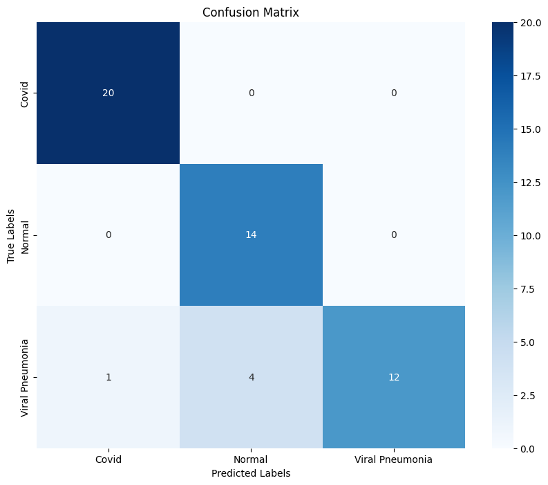

```python
# Get the model's predictions for the test data
y_pred_probabilities = improved_model.predict(X_test)
y_pred = np.argmax(y_pred_probabilities, axis=1)
predicted_labels = [label_encoder.classes_[label] for label in y_pred]

# Create the confusion matrix
cm = confusion_matrix(y_test.tolist(), predicted_labels)

# Plot the confusion matrix
plt.figure(figsize=(10, 8))
sns.heatmap(cm, annot=True, fmt="d", cmap="Blues", xticklabels=label_encoder.classes_, yticklabels=label_encoder.classes_)
plt.xlabel('Predicted Labels')
plt.ylabel('True Labels')
plt.title('Confusion Matrix')
plt.show()
```

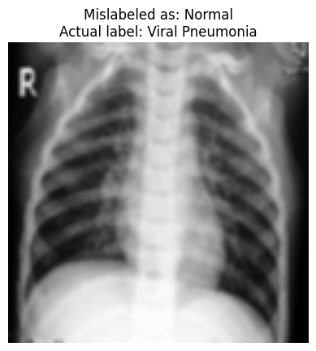

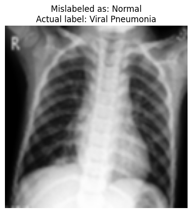

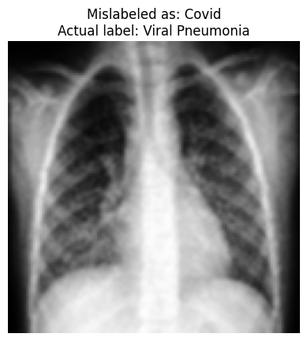

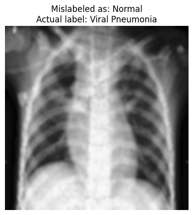

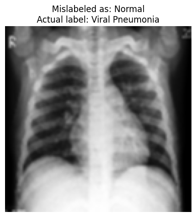

```python
# Find the indices of mislabeled images
mislabeled_indices = np.where(y_pred != y_test_encoded)[0]

# Print the mislabeled images
for index in mislabeled_indices:
    mislabeled_image = X_test[index]
    mislabeled_label = predicted_labels[index]  # Use mapped_labels if available, otherwise use y_pred
    actual_label = y_test.tolist()[index]

    # Display the mislabeled image
    plt.imshow(mislabeled_image, cmap='gray')
    plt.title('Mislabeled as: ' + mislabeled_label + '\nActual label: ' + actual_label)
    plt.axis('off')
    plt.show()
```

```python
# Get the model's predictions for the test data
y_pred = np.argmax(improved_model.predict(X_test), axis=1)

# Compute accuracy
accuracy = accuracy_score(y_test_encoded, y_pred)

# Generate classification report
classification_rep = classification_report(y_test_encoded, y_pred)

# Print the metrics
print("Accuracy:", accuracy)
print("\nClassification Report:\n", classification_rep)
```

```
Accuracy: 0.9019607843137255

Classification Report:
               precision    recall  f1-score   support

           0       0.95      1.00      0.98        20
           1       0.78      1.00      0.88        14
           2       1.00      0.71      0.83        17

    accuracy                           0.90        51
   macro avg       0.91      0.90      0.89        51
weighted avg       0.92      0.90      0.90        51
```

We see that the addition of these common performance enhancers were not effective. Moving forward, it is better to iterate one by one to capture the best performance without the addition of too many new variables. Regardless, this type of iteration also leads to the famous Black Box problem in Machine Learning. Furthermore, whichever model would behave well for this data, would likely fail horribly in deployment given the limited amount of data available.